# willingness to invest in sanitation facilities

Author

Aaron Kipngeno

Published

February 13, 2024

# Introduction

The United Nations Sustainable Development Goal 6.2 aims to achieve access to adequate and equitable sanitation and hygiene for all by 2030. By, 2022, the global access to safely managed sanitation services was reported to be 57% of the population, which equates to 4.6 billion people[@who_2022]. Despite this progress, over 1.5 billion people still lacked basic sanitation services, and 419 million people still practiced open defecation in Sub-Sahara Africa (SSA) and South & central Asia.

Access to improved sanitation in Kenya remains a significant challenge, with only about 32% of the population having access to basic sanitation facilities. This lack of access has led to more than 6 million Kenyans practicing open defecation, contributing to the prevalence of diseases such as diarrhea, typhoid, and cholera. In economic terms, poor sanitation leads to a loss of 0.9% of Kenya’s gross domestic product (GDP) annually. In Bomet County access to improve sanitation is still low at 41% [@dhs_2023]. The effect of poor sanitation on health in Bomet is significant, with over 40% of diarrheal illnesses and intestinal worm infestations attributed to it, as indicated by the Ministry of Health records. Investing in sanitation facilities is crucial to reducing these cases. However, many people do not prioritize sanitation on their investment agenda[ @koskei2013]

The traditional community-led total sanitation (CLTS) approach, as used in Bomet, proposes that once people are made aware of their sanitation problems, they can take action to improve their sanitation status using locally available materials [@njuguna2019a] whether to construc these facilities depends on people’s willingness, preferences, and ability to pay for the facility of their choice. A study by [@mulatya2021] pointed out that various factors, including demographic, socio-cultural, economic, and financial factors to have influence on Households’ willingness, in rural areas of Siaya, Kakamega, and Makueni counties. the findings may not apply to Bomet due to unique contextual factors.

### Objective of the study

#1. To assess the proportion of willingness to invest in sanitation facilities by households in Bomet Sub-county.

#2. To determine the demographic and socio-cultural factors that influences the willingness to invest in sanitation facilities by households in Bomet Sub-county.

#3. To determine the economic and financial factors that influences the willingness to invest in sanitation facilities by householdsin Bomet Sub-county.

# Methodology

Study was Conducted in Bomet County, in Kenya. The sample size was determined using @yamane1973statistics follows: n=N/(1+N(e2) Where, n= desired sample N=Total number of households 30,086 e=sampling error (taken to be ±10%) =30, 806 / (1+30, 806 (0.12).the sample was 100 households. Cluster and simple random sampling technique was used to select households.

Data was analysed using Rtool software for descrptive statistics such frequency, percentage, mean and standrard deviations. Findings was presented using tables, and charts. Inferential statistisc was computed using chi–square test , to examine associations of social and economic factors , and willingness to invest in sanitations.

Ehical considitations was sought in this study.

## Data Import

```r
sanitation <- read_csv(here::here("data/raw/Sanitation_investiment.csv"))
```

### Explore data

```r
head(sanitation)
```

```
# A tibble: 6 × 55
  Gender         Age_bracket  Education  Religion Household_size Know_sanitation
  <chr>          <chr>        <chr>      <chr>             <dbl> <chr>
1 male           18-25        primary    christi…              5 yes
2 male           26-35        secondary  christi…              6 no
3 prefer not say 56 and above college    muslim                4 yes
4 male           46-55        university Other                 5 yes
5 female         26-35        university christi…              8 yes
6 male           36-45        primary    christi…              4 yes
# ℹ 49 more variables: Source_of_information <chr>,
#   Source_of_information_Public_Health_Officers <dbl>,
#   Source_of_information_Community_Health_Volunteers <dbl>,
#   `Source_of_information_ Media` <dbl>,
#   Source_of_information_NGO_Workers <dbl>,
#   Source_of_information_Local_Marketers <dbl>,
#   Source_of_information_Others <dbl>, Presence_of_latrine <chr>, …
```

```r
tail(sanitation)
```

```
# A tibble: 6 × 55
  Gender Age_bracket Education  Religion  Household_size Know_sanitation
  <chr>  <chr>       <chr>      <chr>              <dbl> <chr>
1 female 36-45       secondary  christian              6 yes
2 male   36-45       primary    christian              4 yes
3 female 26-35       secondary  christian              3 yes
4 male   46-55       university christian              5 yes
5 male   36-45       college    christian              5 yes
6 female 18-25       secondary  christian              2 yes
# ℹ 49 more variables: Source_of_information <chr>,
#   Source_of_information_Public_Health_Officers <dbl>,
#   Source_of_information_Community_Health_Volunteers <dbl>,
#   `Source_of_information_ Media` <dbl>,
#   Source_of_information_NGO_Workers <dbl>,
#   Source_of_information_Local_Marketers <dbl>,
#   Source_of_information_Others <dbl>, Presence_of_latrine <chr>, …
```

```r
nrow(sanitation)
```

```
[1] 99
```

```r
ncol(sanitation)
```

```
[1] 55
```

## data cleaning

```r
#data transformations - rename/relocate/muatate/removing
sanitation_clean <- sanitation |>
mutate(id = row_number()) |>
  relocate(id) |>
  janitor::clean_names()

sanitation_clean <- sanitation_clean |>
       rename(community_health_officers =  "source_of_information_community_health_volunteers",
      media ="source_of_information_media",
    ngo_workers = "source_of_information_ngo_workers",
  local_markertes = "source_of_information_local_marketers",
  others =  "source_of_information_others",
  quality_of_toilet = "quality_of_toilet_25",
 latrine_charcteristics = "quality_of_toilet_30",
motivating_factors = "if_yes_motivating_factors",)

sanitation_clean <- sanitation_clean |>
  rename(public_health_officers = "source_of_information_public_health_officers")

#removing column
sanitation_clean$source_of_information = NULL
sanitation_clean$motivating_factors = NULL
sanitation_clean$culture= NULL
sanitation_clean$impacts_of_open_defecation = NULL
```

### converting categorical variables to factors

```r
sanitation_clean <- sanitation_clean |>
  mutate(age_bracket = factor(age_bracket))

sanitation_clean |>
   mutate(gender = factor(gender))
```

```
# A tibble: 99 × 52
      id gender    age_bracket education religion household_size know_sanitation
   <int> <fct>     <fct>       <chr>     <chr>             <dbl> <chr>
 1     1 male      18-25       primary   christi…              5 yes
 2     2 male      26-35       secondary christi…              6 no
 3     3 prefer n… 56 and abo… college   muslim                4 yes
 4     4 male      46-55       universi… Other                 5 yes
 5     5 female    26-35       universi… christi…              8 yes
 6     6 male      36-45       primary   christi…              4 yes
 7     7 female    18-25       primary   christi…              3 no
 8     8 male      46-55       universi… Other                 5 yes
 9     9 male      56 and abo… no educa… christi…              3 yes
10    10 prefer n… 26-35       college   Other                 2 yes
# ℹ 89 more rows
# ℹ 45 more variables: public_health_officers <dbl>,
#   community_health_officers <dbl>, media <dbl>, ngo_workers <dbl>,
#   local_markertes <dbl>, others <dbl>, presence_of_latrine <chr>,
#   type_latrine_own <chr>, disease_prevention <dbl>, dignity <dbl>,
#   privacy <dbl>, safety <dbl>, prestige <dbl>, if_no <chr>,
#   benefit_of_use_latrine <chr>, quality_of_toilet <dbl>, …
```

```r
education_levels <- c("no education", "primary", "secondary", "college", "university")
sanitation_clean <- sanitation_clean |>
  mutate(education = factor(education,levels = education_levels))

income_levels <- c("0-1000", "1001-5000", "5001-10000", "10001-20000","20001-50000", "50001")
sanitation_clean <- sanitation_clean |>
  mutate(income = factor(income, levels = income_levels))

religion_levels <- c("christian",  "muslim", "Other")
sanitation_clean <- sanitation_clean |>
  mutate(religion = factor(religion, levels = religion_levels))

sanitation_clean <- sanitation_clean |>
  mutate(sanitation_organizations = factor(sanitation_organizations),
         employement_status = factor(employement_status),
         willingness_to_invest = factor(willingness_to_invest),
         level_of_willingness = factor(level_of_willingness),
         knowledge_on_financial_institutions = factor(knowledge_on_financial_institutions),
         member_to_savings_and_lendings_groups = factor(member_to_savings_and_lendings_groups),
         loan = factor(loan),
         sanitation_loan = factor(sanitation_loan),
         if_no = factor(if_no),
         know_sanitation = factor(know_sanitation),
         presence_of_latrine = factor(presence_of_latrine),
         type_latrine_own = factor(type_latrine_own),
         benefit_of_use_latrine = factor(benefit_of_use_latrine),
         sanitation_organizations = factor(sanitation_organizations),
         know_sanitation = factor(know_sanitation),
         cost_of_latrine = (cost_of_latrine),
         sanitation_laws = factor(sanitation_laws))
attach(sanitation_clean)

#checking var(class and level)
class(sanitation_clean$benefit_of_use_latrine)
```

```
[1] "factor"
```

```r
levels(sanitation_clean$benefit_of_use_latrine)
```

```
[1] "Don't know" "No"         "Yes"
```

### data cleaning for multiple choice questions

```r
#1 Where do you mainly get information on sanitation?

sanitation_information <- sanitation_clean |>
  select( public_health_officers:others) |>
  pivot_longer(cols = public_health_officers:others,
               names_to = "information",
               values_to = "answer")
sanitation_information|>
  filter(answer == 1) |>
  group_by(information) |>
  count() |>
  mutate(percent = n / nrow(sanitation) * 100)
```

```
# A tibble: 6 × 3
# Groups:   information [6]
  information                   n percent
  <chr>                     <int>   <dbl>
1 community_health_officers    74    74.7
2 local_markertes              10    10.1
3 media                        41    41.4
4 ngo_workers                  19    19.2
5 others                       15    15.2
6 public_health_officers       42    42.4
```

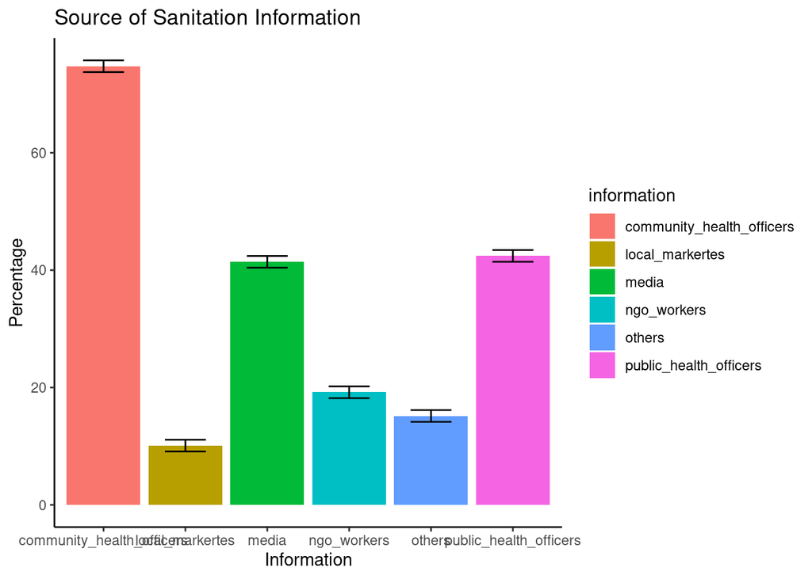

```r
# Create a bar plot for the summarized categorical data
sanitation_information |>
  filter(answer == 1) |>
  group_by(information) |>
  count() |>
  mutate(percent = n / nrow(sanitation) * 100) |>
  ggplot(aes(x = information, y = percent, fill = information)) +
  geom_bar(stat = "identity", position = position_dodge()) +
   geom_errorbar(aes(ymin = percent - 1, ymax = percent + 1), width = 0.5, color = "black") +
  labs(title = "Source of Sanitation Information", x = "Information", y = "Percentage") +
  theme_classic()
```

```r
#2 What are the consequences of not using latrines?(mark all that apply)

motivation <- sanitation_clean |>
  select( disease_prevention:prestige) |>
  pivot_longer(cols = disease_prevention:prestige,
               names_to = "consequences",
               values_to = "answer")
motivation|>
  filter(answer == 1) |>
  group_by(consequences) |>
  count() |>
  mutate(percent = n / nrow(sanitation) * 100)
```

```
# A tibble: 5 × 3
# Groups:   consequences [5]
  consequences           n percent
  <chr>              <int>   <dbl>
1 dignity               40    40.4
2 disease_prevention    50    50.5
3 prestige              11    11.1
4 privacy               28    28.3
5 safety                15    15.2
```

```r
#3 What characteristics would you like to see in your latrine of choice? (mark all that apply)

latrine_charcteristics <- sanitation_clean |>
  select( clean_floor_and_slab:lockable_door) |>
  pivot_longer(cols = clean_floor_and_slab:lockable_door,
               names_to = "quality_of_toilet",
               values_to = "answer")
latrine_charcteristics |>
  filter(answer == 1) |>
  group_by(quality_of_toilet) |>
  count() |>
  mutate(percent = n / nrow(sanitation) * 100)
```

```
# A tibble: 4 × 3
# Groups:   quality_of_toilet [4]
  quality_of_toilet        n percent
  <chr>                <int>   <dbl>
1 clean_floor_and_slab    41    41.4
2 covered_squat_hole      11    11.1
3 lockable_door           68    68.7
4 with_wall_and_roof      80    80.8
```

```r
#4 What cultures do exist in your community that affect owning and use of latrines? (mark all that apply)

culture <- sanitation_clean |>
  select( in_laws_do_not_share :people_living_with_chronic_illnesses_do_not_share) |>
  pivot_longer(cols = in_laws_do_not_share :people_living_with_chronic_illnesses_do_not_share,
               names_to = "existing_cultures",
               values_to = "answer")
culture |>
  filter(answer == 1) |>
  group_by(existing_cultures) |>
  count() |>
  mutate(percent = n / nrow(sanitation) * 100)
```

```
# A tibble: 4 × 3
# Groups:   existing_cultures [4]
  existing_cultures                                     n percent
  <chr>                                             <int>   <dbl>
1 children_do_not_share_with_adults                    37   37.4
2 in_laws_do_not_share                                 41   41.4
3 people_living_with_chronic_illnesses_do_not_share    33   33.3
4 visitors_do_not_share                                 9    9.09
```

```r
#5 What hinders you/people from your community from accessing financial services?(mark all that apply)

loan_factors <- sanitation_clean |>
  select(financial_knowledge:employment_status) |>
  pivot_longer(cols = financial_knowledge:employment_status,
               names_to = "barrier_to _loan_services",
               values_to = "answer")
loan_factors |>
  filter(answer == 1) |>
  group_by(`barrier_to _loan_services`) |>
  count() |>
  mutate(percent = n / nrow(sanitation) * 100)
```

```
# A tibble: 4 × 3
# Groups:   barrier_to _loan_services [4]
  `barrier_to _loan_services`            n percent
  <chr>                              <int>   <dbl>
1 cost_of_service                       24    24.2
2 employment_status                     47    47.5
3 financial_knowledge                   73    73.7
4 physical_distance_to_service_point    18    18.2
```

```r
#filter function
type_of_latrine <- sanitation_clean |>
  filter(!is.na(type_latrine_own)) |>
  group_by(type_latrine_own) |>
  count()
```

### Data visualization

```r
library(ggplot2)
# plot1- bar graph
bar_graph <- ggplot(data = sanitation_clean, aes(x = age_bracket, fill = age_bracket)) +
  geom_bar(stat = "count", position = position_dodge()) +
  facet_grid(~willingness_to_invest) +
  ggtitle("Willingeness to invest in sanitation facilities by Age Bracket") +
  labs(x = "Age Bracket", y = "Count")

#plot2- scatter plot
scatter_plot <- sanitation_clean |>
filter(!is.na(income)) |>
ggplot(aes(household_size))+
  geom_point( stat = "count",aes(color = presence_of_latrine), alpha = 0.5)+
  facet_grid(willingness_to_invest ~ know_sanitation)
#plot- box plot
# Create a box plot
box_plot <- ggplot(sanitation_clean, aes(x = education, y = household_size)) +
  geom_boxplot(fill = "skyblue") +
  labs(title = "Household Size Distribution by eduction level", x = "education level", y = "household size") +
  theme_classic()
```

#saving data file

```r
write_csv(x = sanitation_clean, "/cloud/project/data/processed/sanitation_clean.csv" )
```

# Results

```r
library(gtsummary)
library(ggplot2)
library(gt)
library(tidyverse)
```

Data import

```r
#importing proccesed data

sanitation_clean <- read_csv(here::here("/cloud/project/data/processed/sanitation_clean.csv"))
```

### demographic information of the respondents

```r
 sanitation_clean |>
  select(gender, age_bracket, religion, education) |>
  tbl_summary(
    statistic = list(all_continuous() ~ "{mean} ± {sd}")
  ) |>
  as_gt()
```

Demographic informations of respondemnts

| **Characteristic** | **N = 99**<sup>1</sup> |
| --- | --- |
| gender |  |
| female | 48 (48%) |
| male | 49 (49%) |
| prefer not say | 2 (2.0%) |
| age_bracket |  |
| 18-25 | 6 (6.1%) |
| 26-35 | 23 (23%) |
| 36-45 | 30 (30%) |
| 46-55 | 21 (21%) |
| 56 and above | 19 (19%) |
| religion |  |
| christian | 69 (70%) |
| muslim | 10 (10%) |
| Other | 20 (20%) |
| education |  |
| college | 21 (21%) |
| no education | 19 (19%) |
| primary | 28 (28%) |
| secondary | 21 (21%) |
| university | 10 (10%) |

<sup>1</sup> n (%)

```r
 summary(household_size)
```

```
   Min. 1st Qu.  Median    Mean 3rd Qu.    Max.
  2.000   4.000   5.000   4.768   6.000   8.000
```

### #data visualization of demographic characteristics of respondents

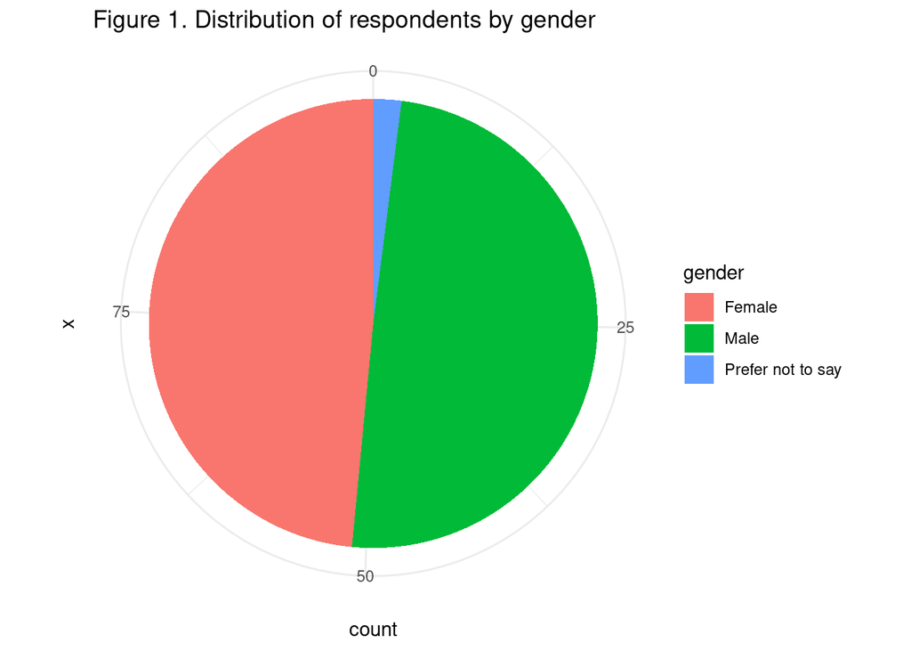

```r
#pie chart for gender distributions
#Create a data frame with the gender distribution
gender_data <- data.frame(
  gender = c("Male", "Female", "Prefer not to say"),
  count = c(49, 48,2))

ggplot(gender_data, aes(x = "", y = count, fill = gender)) +
  geom_bar(stat = "identity", width = 1) +
  coord_polar("y") +
  labs(title = "Figure 1. Distribution of respondents by gender", fill = "gender") +
  theme_minimal()
```

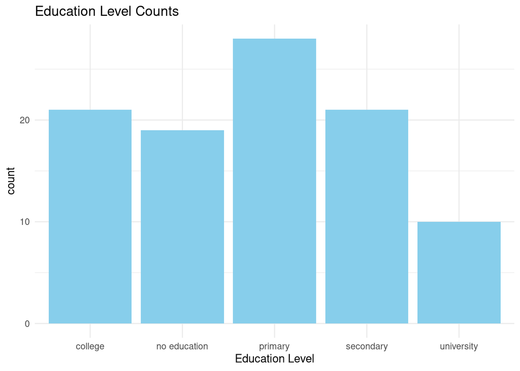

```r
#bar graph for education with error bar.
ggplot(sanitation_clean, aes(education, fill = education)) +
  geom_bar(stat = "count", fill = "skyblue") +
  labs(title = "Education Level Counts", x = "Education Level", y = "count") +
  theme_minimal()
```

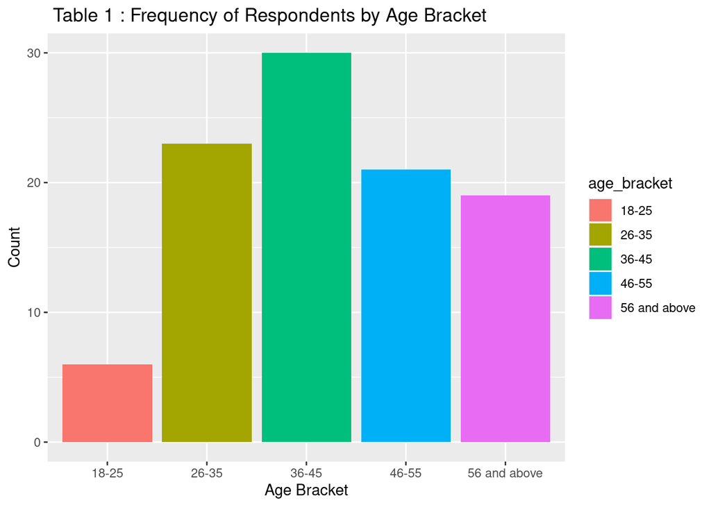

```r
#bar graph showing age_bracket of respondents against frequency "count"
ggplot(sanitation_clean, aes(x = age_bracket, fill = age_bracket)) +
  geom_bar(stat = "count") +
  labs(title = " Table 1 : Frequency of Respondents by Age Bracket", x = "Age Bracket", y = "Count")
```

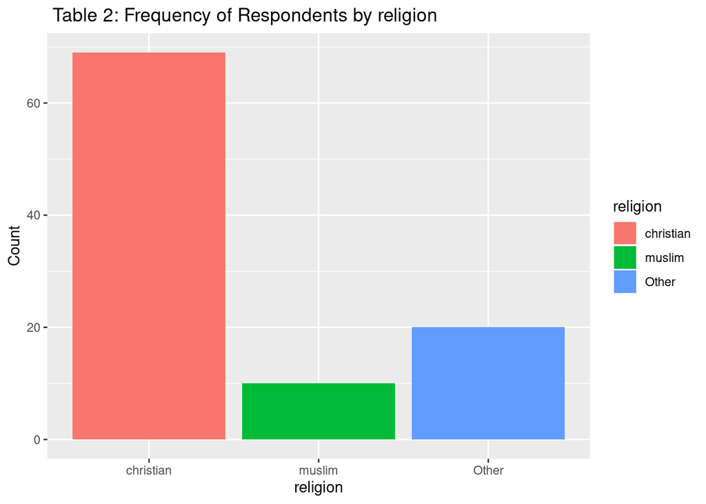

```r
#bar graph showing relogion of respondents against frequency "count"
ggplot(sanitation_clean,
       aes(x = religion, fill = religion))+
  geom_bar(stat = "count")+
  labs(title = " Table 2: Frequency of Respondents by religion", x = "religion", y = "Count")
```

```r
# Create a histogram for the household_size variable
# Calculate the mean, standard deviation, and size of data
mean_hs <- mean(sanitation_clean$household_size)
sd_hs <- sd(sanitation_clean$household_size)
size_hs <- nrow(sanitation_clean)
```

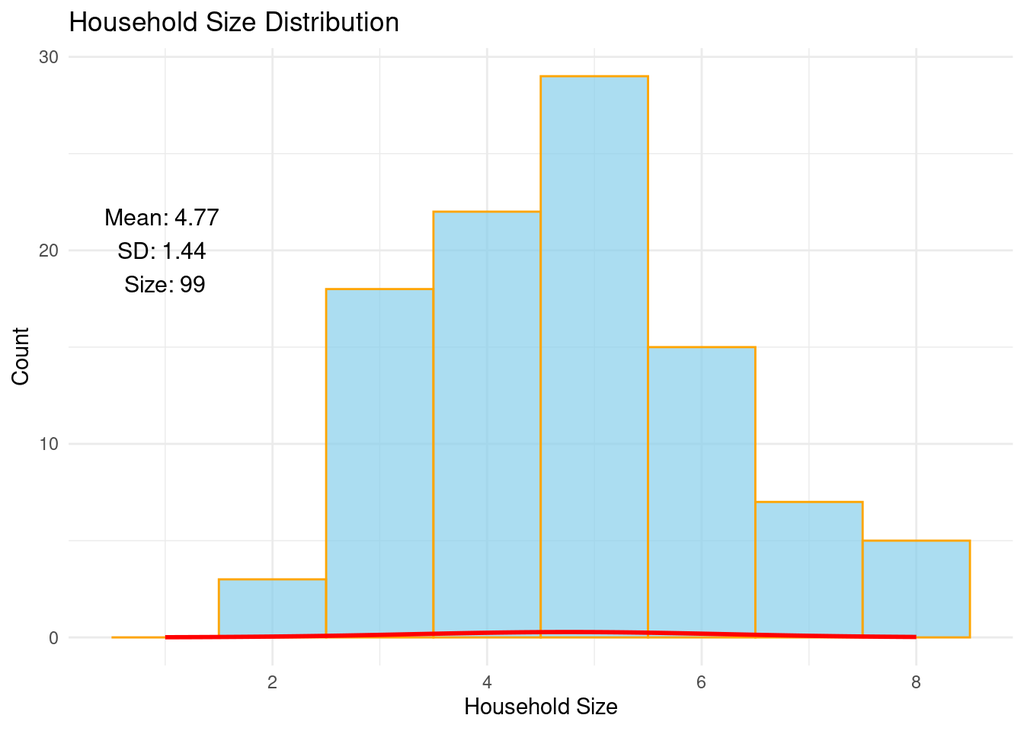

household size distributions

```r
#Create a histogram for the household_size variable
ggplot(sanitation_clean, aes(x = household_size)) +
  geom_histogram(binwidth = 1, fill = "skyblue", color = "orange", alpha = 0.7) +
  stat_function(fun = dnorm, args = list(mean = mean_hs, sd = sd_hs), color = "red", size = 1)+
  annotate("text", x = 1, y = 20, label = paste("Mean:", round(mean_hs, 2), "\nSD:", round(sd_hs, 2), "\nSize:", size_hs), color = "black", size = 4) +
  labs(title = "Household Size Distribution", x = "Household Size", y = "Count") +
  theme_minimal()
```

### #willingness to invest in sanitation

```r
#|lable: tbl-willingness
#|tbl-cap: proportion willing to invesrt in sanitaions
sanitation_clean |>
  tbl_summary(include = c(willingness_to_invest))
```

| **Characteristic** | **N = 99**<sup>1</sup> |
| --- | --- |
| willingness_to_invest | 76 (77%) |

<sup>1</sup> n (%)

```r
#|lable: tbl-level
#|tbl-cap: level of willingness to invest

sanitation_clean |>
  tbl_cross(row = level_of_willingness,
            col = willingness_to_invest,
            percent = "cell") |>
  add_p()
```

|  | willingness_to_invest no | willingness_to_invest yes | Total | p-value<sup>1</sup> |  |  |
| --- | --- | --- | --- | --- | --- | --- |
| level_of_willingness |  |  |  |  |  | <0.001 |
| Not willing | 19 (19%) | 10 (10%) | 29 (29%) |  |  |  |
| Very much willing | 0 (0%) | 20 (20%) | 20 (20%) |  |  |  |
| Willing | 2 (2.0%) | 46 (46%) | 48 (48%) |  |  |  |
| Unknown | 2 (2.0%) | 0 (0%) | 2 (2.0%) |  |  |  |
| Total | 23 (23%) | 76 (77%) | 99 (100%) |  |  |  |

<sup>1</sup> Fisher’s exact test

### #social factors and willingness to invest in sanitation

#### #chi-Square test statistics

A Pearson’s chi-squared test was conducted to examine the relationship between Social factors and willingness to invest in sanitation.

```r
#genderand willinness to invest
##The results indicated a non-significant association between the two variables, χ²(df = 2, N = [99]) = 3.06, p = 0.216

s1 <- table(sanitation_clean$willingness_to_invest, sanitation_clean$gender)
chisq.test(s1)
```

```
    Pearson's Chi-squared test

data:  s1
X-squared = 3.0615, df = 2, p-value = 0.2164
```

```r
#willingness to invest and age bracket
#The test yielded a chi-squared statistic of 1.3313 with 4 degrees of freedom, and a p-value of 0.856. This suggests that there is no evidence to reject the null hypothesis, indicating that there is no association between the variables

s2 <- table(sanitation_clean$willingness_to_invest, sanitation_clean$age_bracket)
chisq.test(s2)
```

```
    Pearson's Chi-squared test

data:  s2
X-squared = 1.3313, df = 4, p-value = 0.856
```

```r
# willingess to invest & religion
#The analysis revealed no significant association, χ²(df = 2, N = 99) = 9.85, p = 0.0073
s3 <- table(sanitation_clean$willingness_to_invest, sanitation_clean$religion)
chisq.test(s3)
```

```
    Pearson's Chi-squared test

data:  s3
X-squared = 9.845, df = 2, p-value = 0.007281
```

```r
#willingness to invest and presence of latine
#The analysis revealed a significant association, χ²(1, N = [99]) = 13.38, p = 0.0003
s4 <- table(sanitation_clean$willingness_to_invest, sanitation_clean$presence_of_latrine)
chisq.test(s4)
```

```
    Pearson's Chi-squared test with Yates' continuity correction

data:  s4
X-squared = 13.375, df = 1, p-value = 0.000255
```

```r
# willingness to invest & benefit to use llatrine
#The analysis revealed a significant association, χ²(2, N = [99) = 19.33, p = 6.34e-05
s5 <- table(sanitation_clean$willingness_to_invest, sanitation_clean$benefit_of_use_latrine)
chisq.test(s5)
```

```
    Pearson's Chi-squared test

data:  s5
X-squared = 19.332, df = 2, p-value = 6.34e-05
```

```r
#willingess to invest in sanitation& sanitation laws
s6 <-table(sanitation_clean$willingness_to_invest, sanitation_clean$sanitation_laws)
chisq.test(s6)
```

```
    Pearson's Chi-squared test with Yates' continuity correction

data:  s6
X-squared = 6.7159, df = 1, p-value = 0.009556
```

### #economic factors and willingness to invest in sanitation

#chi-square test statistics.

```r
#influence of employement status
#no significant association p value = 0.02 > 0.005
e1 <- table(sanitation_clean$willingness_to_invest, sanitation_clean$employement_status)
chisq.test(e1)
```

```
    Pearson's Chi-squared test

data:  e1
X-squared = 7.7276, df = 2, p-value = 0.02099
```

```r
# influnce of household income
#The analysis revealed a significant association, χ²(4, N = [99]) = 16.22, p = 0.0027
e2 <- table(sanitation_clean$willingness_to_invest, sanitation_clean$income)
chisq.test(e2)
```

```
    Pearson's Chi-squared test

data:  e2
X-squared = 16.215, df = 4, p-value = 0.002744
```

```r
#presence sanitation organizations
#the analysis revealed a significant association, χ²(1, N = [99]) = 12.07, p = 0.0005
e3 <- table(sanitation_clean$willingness_to_invest, sanitation_clean$sanitation_organizations)
chisq.test(e3)
```

```
    Pearson's Chi-squared test with Yates' continuity correction

data:  e3
X-squared = 12.066, df = 1, p-value = 0.0005135
```

```r
# influence of being member of saving and lending groups
# signifiacnt association at χ²(1, N= 99)= 10.692, p = 001.
e4<- table(sanitation_clean$willingness_to_invest, sanitation_clean$member_to_savings_and_lendings_groups)
chisq.test(e4)
```

```
    Pearson's Chi-squared test with Yates' continuity correction

data:  e4
X-squared = 10.692, df = 1, p-value = 0.001076
```

# Conclusions

The study found that the majority of respondents, 76%, were willing to invest in sanitation. There could be several reasons for this willingness, including the desire for personal safety and privacy, fear of penalties and fines, fear of disease outbreaks, raising social status, and the need for a safe place for defecation/urination.

The study found that the majority of social factors investigated had no significant associations with the willingness to invest in sanitation, except for the benefit of use and the presence of a toilet, which showed significant associations at a p-value of less than .005. This could be due to various reasons, including the specific emphasis on the benefit of use and the presence of a toilet in influencing individuals’ decisions to invest in sanitation. Additionally, the findings may suggest that these two factors, in particular, play a more prominent role in shaping attitudes and behaviors towards sanitation investment compared to other social factors that were examined in the study

Several economic factors were found to have significant associations with the willingness to invest in sanitation, including household income, the presence of organizations that promote sanitation, and being a member of saving and lending groups at p value (<.005). This could be due to increasing access to financial resources and promoting economic development could help to improve sanitation investment.